# Reading notes chap 5-7

Haoluan Chen

9/22/2020

## 5 Converting to and from non-tidy formats

Most of the existing R tools for NLP, besides the tidy package are not compatible with the tidy text format(one-token-per-document-per-row). In this chapter we are making connections between the tidy text format with other important packages and data structures, which allows us to use the existing text mining packages/tidy tools based on the context.

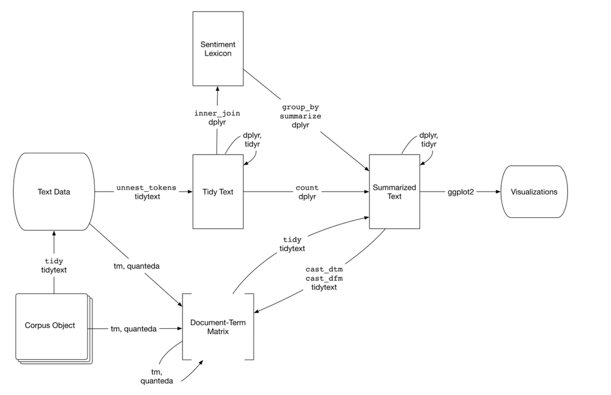

```r
knitr::include_graphics('flow chart.png')
```

## 5.1 Tidying a document-term matrix

One of the most common structures that text mining packages work with is the document-term matrix. The document-term matrix is a matrix where:

- Each row represents one documents
- Each column represents one term
- Each value (typically) contains the number of appearances of that term in that document.

Since most terms do not occur(they have the value zero), the document-term matrix are usually implemented as sparse matrices.

document-term matrix object cannot be used directly with tidy tools, so the tidytext package can convert between two formats.

- tidy() turns a document-term matrix into a tidy data frame.
- cast() turns a tidy data frame into matrix. The tidytext provides three variation, each converting to a different type of matrix:
  - cast_sparse() - convert to a sparse matrix
  - cast_dtm() - convert to a document-term matrix
  - cast_dfm() - convert to a dfm(document feature matrix) object

A document-term matrix is typically comparable to a tidy data frame after count or a group_by/summarize that contains count or other statistics for each combination of a term and document.

## 5.1.5 Tidying DocumentTermMatrix objects

I was not able to find any data that is in the document-term matrix form. So, I am using the data set provide in the text book.

```r
data("AssociatedPress", package = "topicmodels")
AssociatedPress
```

```
## <<DocumentTermMatrix (documents: 2246, terms: 10473)>>
## Non-/sparse entries: 302031/23220327
## Sparsity           : 99%
## Maximal term length: 18
## Weighting          : term frequency (tf)
```

There is 2246 documents and 10473 terms in the data set. We could see the terms in the document with the Terms() function

```r
terms <- Terms(AssociatedPress)
head(terms)
```

```
## [1] "aaron"      "abandon"    "abandoned"  "abandoning" "abbott"
## [6] "abboud"
```

We can turn the document-term matrix into a tidy data format by using tidy()

```r
tidy_data <- tidy(AssociatedPress)
tidy_data
```

```
## # A tibble: 302,031 x 3
##    document term       count
##       <int> <chr>      <dbl>
##  1        1 adding         1
##  2        1 adult          2
##  3        1 ago            1
##  4        1 alcohol        1
##  5        1 allegedly      1
##  6        1 allen          1
##  7        1 apparently     2
##  8        1 appeared       1
##  9        1 arrested       1
## 10        1 assault        1
## # ... with 302,021 more rows
```

We have three variables in the tidy_data, document, term and count. This is something that I am familiar with. We can perform sentiment analysis or plot as we did in earlier chapter.

```r
ap_sentiments_bing <- tidy_data %>%
  inner_join(get_sentiments("bing"), by = c(term = "word"))
ap_sentiments_bing
```

```
## # A tibble: 30,094 x 4
##    document term    count sentiment
##       <int> <chr>   <dbl> <chr>
##  1        1 assault     1 negative
##  2        1 complex     1 negative
##  3        1 death       1 negative
##  4        1 died        1 negative
##  5        1 good        2 positive
##  6        1 illness     1 negative
##  7        1 killed      2 negative
##  8        1 like        2 positive
##  9        1 liked       1 positive
## 10        1 miracle     1 positive
## # ... with 30,084 more rows
```

```r
ap_sentiments_afinn <- tidy_data %>%
  inner_join(get_sentiments("afinn"), by = c(term = "word"))
ap_sentiments_afinn
```

```
## # A tibble: 31,665 x 4
##    document term     count value
##       <int> <chr>    <dbl> <dbl>
##  1        1 arrested     1    -3
##  2        1 big          1     1
##  3        1 charged      1    -3
##  4        1 charges      1    -2
##  5        1 crying       1    -2
##  6        1 death        1    -2
##  7        1 died         1    -3
##  8        1 felony       1    -3
##  9        1 fire         1    -2
## 10        1 fired        2    -2
## # ... with 31,655 more rows
```

```r
ap_sentiments_nrc <- tidy_data %>%
  inner_join(get_sentiments("nrc"), by = c(term = "word"))
ap_sentiments_nrc
```

```
## # A tibble: 147,609 x 4
##    document term     count sentiment
##       <int> <chr>    <dbl> <chr>
##  1        1 assault      1 anger
##  2        1 assault      1 fear
##  3        1 assault      1 negative
##  4        1 boy          4 disgust
##  5        1 boy          4 negative
##  6        1 building     1 positive
##  7        1 church       1 anticipation
##  8        1 church       1 joy
##  9        1 church       1 positive
## 10        1 church       1 trust
## # ... with 147,599 more rows
```

First looking at the sentiments from bing package, we cab see the postive or negative words in our data.

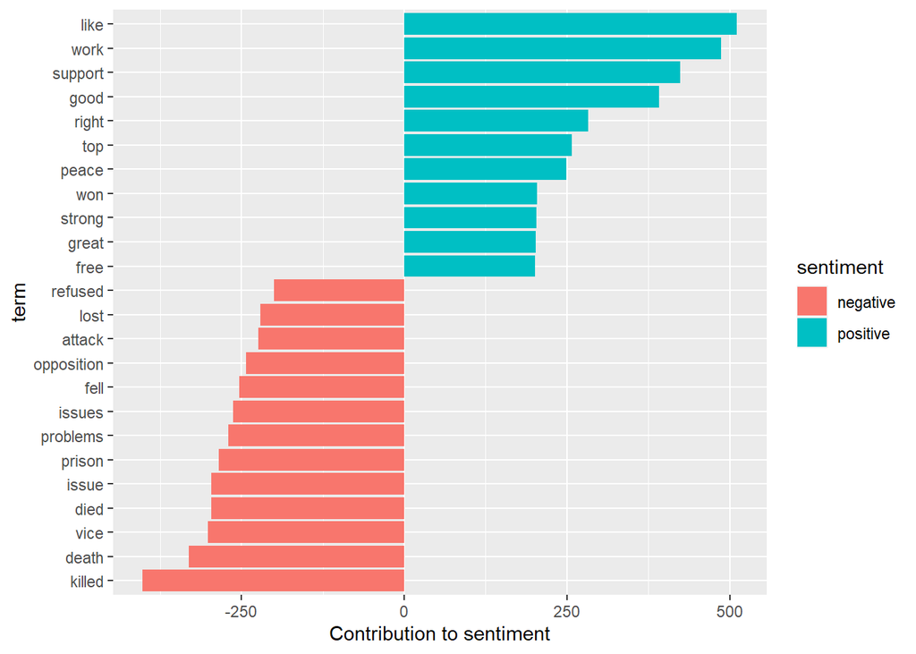

```r
ap_sentiments_bing%>%
  count(sentiment, term, wt = count) %>%
  filter(n >= 200) %>%
  mutate(n = ifelse(sentiment == "negative", -n, n)) %>%
  mutate(term = reorder(term, n)) %>%
  ggplot(aes(term, n, fill = sentiment)) +
  geom_bar(stat = "identity") +
  ylab("Contribution to sentiment") +
  coord_flip()
```

trying out theme_minimal() and theme_classic() and theme_clean()

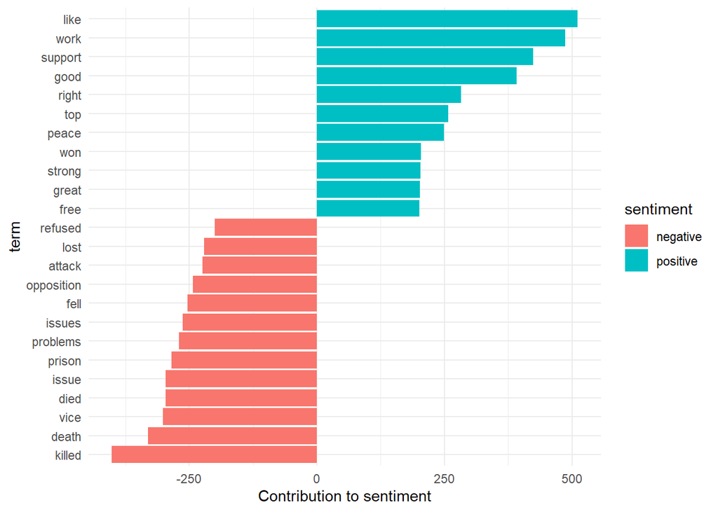

```r
ap_sentiments_bing%>%
  count(sentiment, term, wt = count) %>%
  ungroup() %>%
  filter(n >= 200) %>%
  mutate(n = ifelse(sentiment == "negative", -n, n)) %>%
  mutate(term = reorder(term, n)) %>%
  ggplot(aes(term, n, fill = sentiment)) +
  geom_bar(stat = "identity") +
  ylab("Contribution to sentiment") +
  coord_flip()+
  theme_minimal()
```

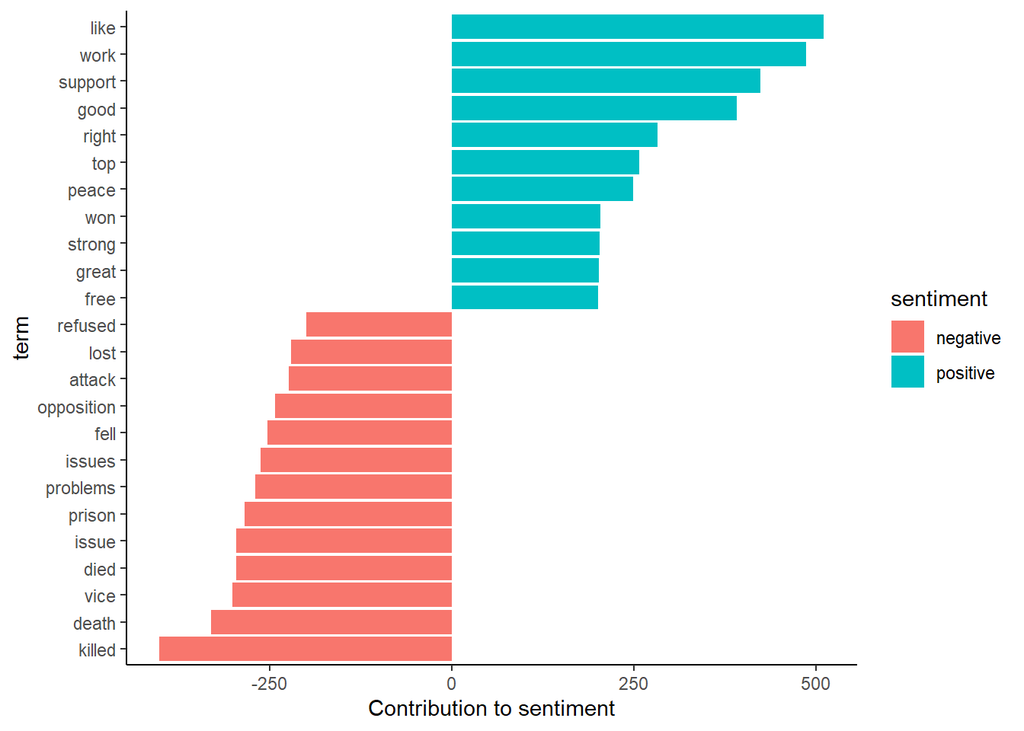

```r
ap_sentiments_bing%>%
  count(sentiment, term, wt = count) %>%
  ungroup() %>%
  filter(n >= 200) %>%
  mutate(n = ifelse(sentiment == "negative", -n, n)) %>%
  mutate(term = reorder(term, n)) %>%
  ggplot(aes(term, n, fill = sentiment)) +
  geom_bar(stat = "identity") +
  ylab("Contribution to sentiment") +
  coord_flip()+
  theme_classic()
```

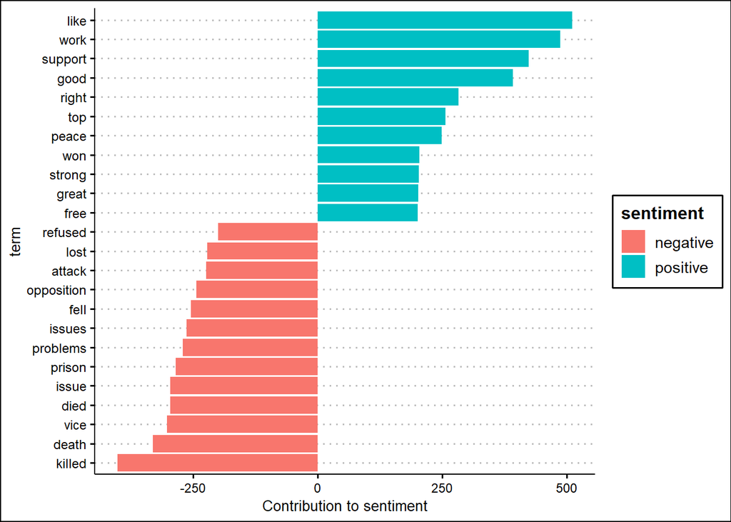

```r
ap_sentiments_bing%>%
  count(sentiment, term, wt = count) %>%
  ungroup() %>%
  filter(n >= 200) %>%
  mutate(n = ifelse(sentiment == "negative", -n, n)) %>%
  mutate(term = reorder(term, n)) %>%
  ggplot(aes(term, n, fill = sentiment)) +
  geom_bar(stat = "identity") +
  ylab("Contribution to sentiment") +
  coord_flip()+
  theme_clean()
```

## 5.1.2 Tidying dfm objects

Other text mining packages provide alternative implementations of document-term matrices, such as the dfm (document-feature matrix) class.

There is no explanation for DFM, This is what I found on Google: “refers to documents in rows and “features” as columns"

What is features in this context? What is the difference between DFM and DTM?

I do not know how to turn data into DFM right now. So, I am using data set from the text book

```r
data("data_corpus_inaugural", package = "quanteda")
inaug_dfm <- quanteda::dfm(data_corpus_inaugural, verbose = FALSE)
inaug_dfm
```

```
## Document-feature matrix of: 58 documents, 9,360 features (91.8% sparse) and 4 docvars.
##                  features
## docs              fellow-citizens  of the senate and house representatives
##   1789-Washington               1  71 116      1  48     2               2
##   1793-Washington               0  11  13      0   2     0               0
##   1797-Adams                    3 140 163      1 130     0               2
##   1801-Jefferson                2 104 130      0  81     0               0
##   1805-Jefferson                0 101 143      0  93     0               0
##   1809-Madison                  1  69 104      0  43     0               0
##                  features
## docs              : among vicissitudes
##   1789-Washington 1     1            1
##   1793-Washington 1     0            0
##   1797-Adams      0     4            0
##   1801-Jefferson  1     1            0
##   1805-Jefferson  0     7            0
##   1809-Madison    0     0            0
## [ reached max_ndoc ... 52 more documents, reached max_nfeat ... 9,350 more features ]
```

Use tidy() to turn the DFM into tidy format

```r
inaug_td <- tidy(inaug_dfm)
inaug_td
```

```
## # A tibble: 44,710 x 3
##    document        term            count
##    <chr>           <chr>           <dbl>
##  1 1789-Washington fellow-citizens     1
##  2 1797-Adams      fellow-citizens     3
##  3 1801-Jefferson  fellow-citizens     2
##  4 1809-Madison    fellow-citizens     1
##  5 1813-Madison    fellow-citizens     1
##  6 1817-Monroe     fellow-citizens     5
##  7 1821-Monroe     fellow-citizens     1
##  8 1841-Harrison   fellow-citizens    11
##  9 1845-Polk       fellow-citizens     1
## 10 1849-Taylor     fellow-citizens     1
## # ... with 44,700 more rows
```

Now, we may perform tf_idf calculation to see the important words in each document.

```r
inaug_tf_idf <- inaug_td %>%
  bind_tf_idf(term, document, count) %>%
  arrange(desc(tf_idf))

inaug_tf_idf
```

```
## # A tibble: 44,710 x 6
##    document        term        count      tf   idf tf_idf
##    <chr>           <chr>       <dbl>   <dbl> <dbl>  <dbl>
##  1 1793-Washington arrive          1 0.00680  4.06 0.0276
##  2 1793-Washington upbraidings     1 0.00680  4.06 0.0276
##  3 1793-Washington violated        1 0.00680  3.37 0.0229
##  4 1793-Washington willingly       1 0.00680  3.37 0.0229
##  5 1793-Washington incurring       1 0.00680  3.37 0.0229
##  6 1793-Washington previous        1 0.00680  2.96 0.0201
##  7 1793-Washington knowingly       1 0.00680  2.96 0.0201
##  8 1793-Washington injunctions     1 0.00680  2.96 0.0201
##  9 1793-Washington witnesses       1 0.00680  2.96 0.0201
## 10 1793-Washington besides         1 0.00680  2.67 0.0182
## # ... with 44,700 more rows
```

Visualize the words most specific to each document

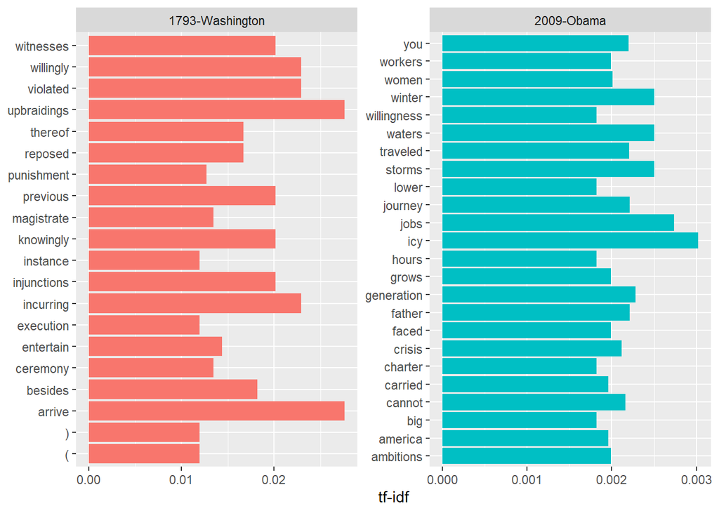

```r
inaug_tf_idf %>%
  group_by(document) %>%
  filter(document == "1793-Washington" | document == "2009-Obama") %>%
  top_n(20, tf_idf) %>%
  arrange(desc(tf_idf)) %>%
  ungroup() %>%
  ggplot(aes(term, tf_idf, fill = document)) +
  geom_col(show.legend = FALSE) +
  labs(x = NULL, y = "tf-idf") +
  facet_wrap(~document, ncol = 2, scales = "free") +
  coord_flip()
```

Notice that “(” and “)” are mark as a term, in the data set. But using unnest_tokens will remove them.

We can also get a visualization of the changes in word usage from year to year.

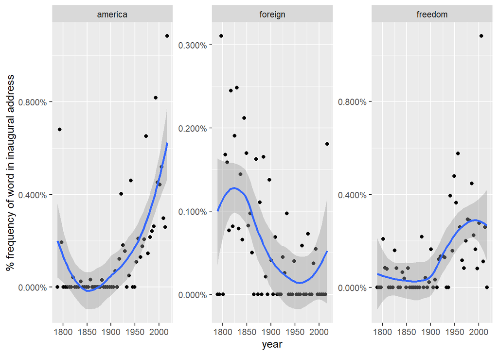

```r
year_term_counts <- inaug_td %>%
  extract(document, "year", "(\\d+)", convert = TRUE) %>%
  complete(year, term, fill = list(count = 0)) %>%
  group_by(year) %>%
  mutate(year_total = sum(count))

year_term_counts %>%
  filter(term %in% c("america", "foreign", "freedom")) %>%
  ggplot(aes(year, count / year_total)) +
  geom_point() +
  geom_smooth() +
  facet_wrap(~ term, scales = "free_y") +
  scale_y_continuous(labels = scales::percent_format()) +
  ylab("% frequency of word in inaugural address")
```

## 5.2 Casting tidy text data into a matrix

Use cast_dtm to cast a tidy data into document-term matrix

```r
tidy_data %>%
  cast_dtm(document, term, count)
```

```
## <<DocumentTermMatrix (documents: 2246, terms: 10473)>>
## Non-/sparse entries: 302031/23220327
## Sparsity           : 99%
## Maximal term length: 18
## Weighting          : term frequency (tf)
```

We could also cast the tidy data into a document-feature matrix object using cast_dfm()

```r
tidy_data %>%
  cast_dfm(document, term, count)
```

```
## Document-feature matrix of: 2,246 documents, 10,473 features (98.7% sparse).
##     features
## docs adding adult ago alcohol allegedly allen apparently appeared arrested
##    1      1     2   1       1         1     1          2        1        1
##    2      0     0   0       0         0     0          0        1        0
##    3      0     0   1       0         0     0          0        1        0
##    4      0     0   3       0         0     0          0        0        0
##    5      0     0   0       0         0     0          0        0        0
##    6      0     0   2       0         0     0          0        0        0
##     features
## docs assault
##    1       1
##    2       0
##    3       0
##    4       0
##    5       0
##    6       0
## [ reached max_ndoc ... 2,240 more documents, reached max_nfeat ... 10,463 more features ]
```

We can also turn the news data in chap 1-4 into document-term matrix

## 5.3 Tidying corpus objects with metadata

Some data structures are designed to store document collections before tokenization, often called a “corpus”. A corpus object is structured like a list, with each item containing both text and metadata(infomation such as the author, id, language).

We can also turn corpus into tidy format by using tidy(), and perform any text mining techniques such as sentiment analysis and tf-idf.

## 5.4 Summary

Text data may be organized in many different format for different purpose, we may need to convert it between different form. For example, converting tidy text data frame into document-term matrices.

## 6 Topic modeling

When we have collections of documents, we may want to divide into natural groups so that we can understand them separately. Topic modeling is a method for unsupervised classification of such documents, similar to clustering.

Laten Dirichlet allocation (LDA) is a popular method for fitting a topic model. LDA treats each document as a mixture of topics, and each topic contains mixture of words. This allows documents to have same terms, rather than separate each term into discrete groups.

A updated flow chart:

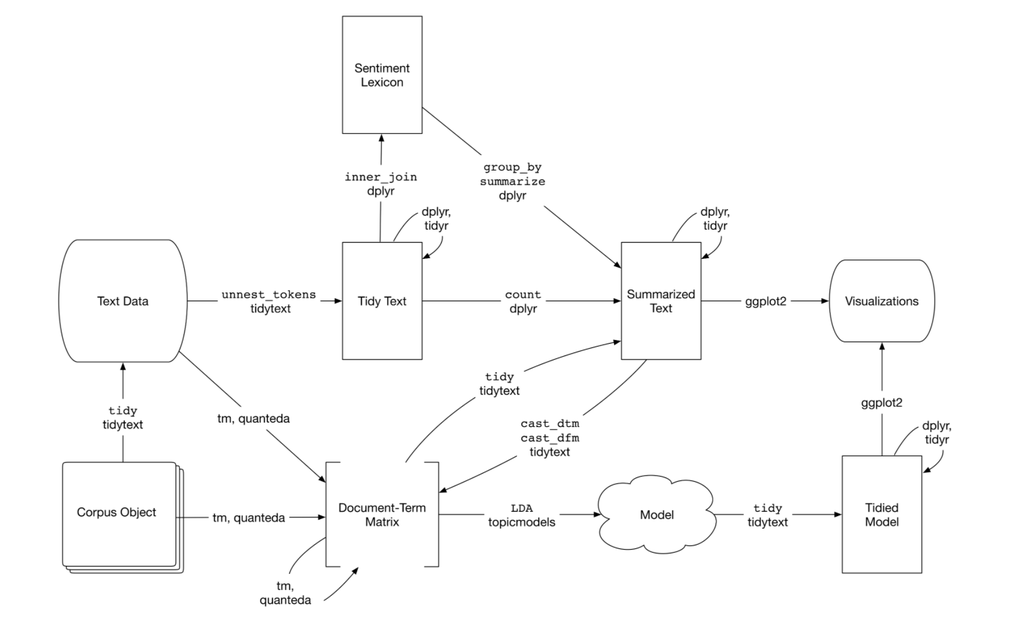

```r
knitr::include_graphics('flow chart 2.png')
```

In this chapter, we’ll learn to work with LDA objects from the topicmodels package, particularly tidying such models so that they can be manipulated with ggplot2 and dplyr. We’ll also explore an example of clustering chapters from several books, where we can see that a topic model “learns” to tell the difference between the four books based on the text content.

## 6.1 Latent Dirichlet allocation

Two principles of Latent Dirichlet allocation:

- Every document is a mixture of topics. (each document may contain words from several topics. In a two-topic model "Document 1 is 90% topic A and 10% topic B, while Document 2 is 30% topic A and 70% topic B.)
- Every topic is a mixture of words. (two-topic model of American news, with one topic for “politics” and one for “entertainment.” The most common words in the politics topic might be “President”, “Congress”, and “government”, while the entertainment topic may be made up of words such as “movies”, “television”, and “actor”. Importantly, words can be shared between topics; a word like “budget” might appear in both equally.)

LDA is a mathematical methods that estimates the mixture of words associated with each topic and mixture of topics that describes each document

Applying LDA to my news data

```r
news_dtm
```

```
## <<DocumentTermMatrix (documents: 3, terms: 567)>>
## Non-/sparse entries: 652/1049
## Sparsity           : 62%
## Maximal term length: 14
## Weighting          : term frequency (tf)
```

```r
news_lda <- LDA(news_dtm, k = 2, control = list(seed = 1234))
news_lda
```

```
## A LDA_VEM topic model with 2 topics.
```

## 6.1.1 Word-topic probabilities

The tidytext package provides this method for extracting the per-topic-per-word probabilities, called $β$ (“beta”), from the LDA model.

```r
news_topics <- tidy(news_lda, matrix = "beta")
```

We can use top_n() to find the 10 terms that are most common within each topic

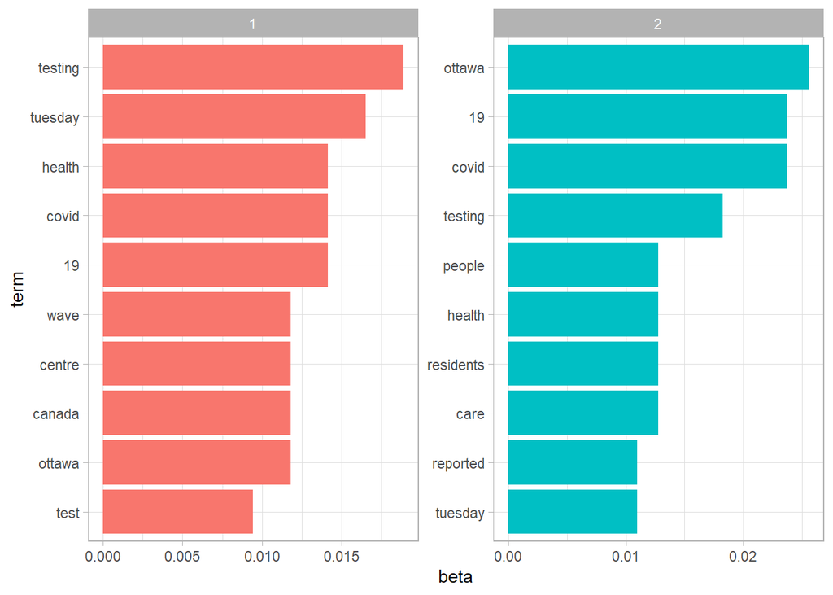

```r
news_top_terms <- news_topics %>%
  group_by(topic) %>%
  top_n(10, beta) %>%
  ungroup() %>%
  arrange(topic, -beta)

news_top_terms %>%
  mutate(term = reorder_within(term, beta, topic)) %>%
  ggplot(aes(term, beta, fill = factor(topic))) +
  geom_col(show.legend = FALSE) +
  facet_wrap(~ topic, scales = "free") +
  coord_flip() +
  scale_x_reordered()+
  theme_light()
```

The plot shows the most common words for two topic, “testing”, “Ottawa”, “covid-19” are in both topic. This is an advantage of topic modeling as opposed to “hard clustering” methods: topics used in natural language could have some overlap in terms of words.

As an alternative, we could consider the terms that had the greatest difference in  
$β$ between topic 1 and topic 2. This can be estimated based on the log ratio of the two:$log_2(\frac{\beta_2}{\beta_1})$ (a log ratio is useful because it makes the difference symmetrical).

```r
beta_spread <- news_topics %>%
  mutate(topic = paste0("topic", topic)) %>%
  spread(topic, beta) %>%
  filter(topic1 > .008 | topic2 > .008) %>% # filter the relevant common words
  mutate(log_ratio = log2(topic2 / topic1))

beta_spread
```

```
## # A tibble: 25 x 4
##    term          topic1   topic2 log_ratio
##    <chr>          <dbl>    <dbl>     <dbl>
##  1 19          1.42e- 2 2.37e- 2     0.745
##  2 assessment  9.43e- 3 1.82e- 3    -2.37
##  3 canada      1.18e- 2 1.98e-33  -102.
##  4 care        2.07e-31 1.28e- 2    95.6
##  5 centre      1.18e- 2 4.50e-33  -101.
##  6 close       1.33e-32 9.12e- 3    99.1
##  7 coronavirus 9.43e- 3 7.14e-31   -93.4
##  8 covid       1.42e- 2 2.37e- 2     0.745
##  9 day         9.43e- 3 7.30e- 3    -0.370
## 10 health      1.42e- 2 1.28e- 2    -0.148
## # ... with 15 more rows
```

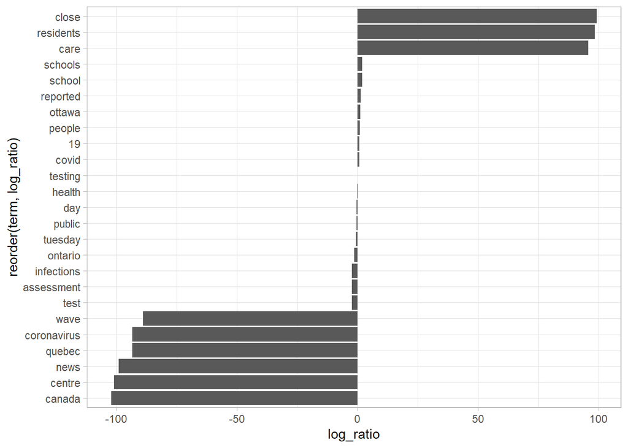

```r
beta_spread %>%
  ggplot(aes(reorder(term, log_ratio), log_ratio)) +
  geom_col(show.legend = FALSE) +
  coord_flip() +
  scale_x_reordered()+
  theme_light()
```

In the bar plot, We can see the Words with the greatest difference in $\beta$ probability between topic 2 and topic 1. (log ration of 1 means $beta_2$ are twice as large as $\beta_2$, log ratio of -1 means $\beta_1$ is twice as large then $\beta_2$)

Because we have a small data set and all the news data are related to covid-19. So, our output is not very interesting.

## Document-topic probabilities

Besides estimating each topic as a mixture of words, LDA also models each document as a mixture of topics. We can examine the per-document-per-topic probabilities, called $\gamma$, with the matrix = “gamma” argument in tidy()

```r
news_documents <- tidy(news_lda, matrix = "gamma")
news_documents
```

```
## # A tibble: 6 x 3
##   document topic     gamma
##   <chr>    <int>     <dbl>
## 1 1            1 1.00
## 2 2            1 0.999
## 3 3            1 0.0000774
## 4 1            2 0.000115
## 5 2            2 0.000757
## 6 3            2 1.00
```

Each of the gamma values is an estimated proportion of words from that document that are generated form that topic. Our model estimated that 99.9% of the words in document 1 were generated from topic 1. Having gamma close to 0 means that it is mostly words generated from other topic.

## 6.2 Example: the great library heist

In this section, the textbook uses four book data set, and perform LDA topic modeling as we did in 6.1. So, I am going over general procedure of LDA topic modeling analysis.

- First of all, we need to know the format of our data set. If our data set is in DTM, we will have to turn in into tidy format by using tidy(). Then some data manipulation may be needed
- use unnest_tokens() to separate the text into words then remove stop words by anti_join()
- find document-word count by using count()
- turn the data into DTM format by using cast_dtm()
- use LDA() to build LDA model, specify value k, where k is the number of topics
- examine per-topic-per-word probabilities by using tidy(data, matrix = “beta”), then plot using ggplot to get a visualization
- examine per-document-per-topic probabilities by using tidy(data, matrix = “gamma”) then plot using ggplot to get a visualiaztion
- find which words in each document were assigned to which topic by using augment()
- if we already know the cluster label, we may find which words were incorrectly classified and create a confusion matrix to show how often words from one topic were assigned to another.

## 6.3 Alternative LDA implementations

The LDA() function in the topicmodels package is only one implementation of the latent Dirichlet allocation algorithm. The mallet package also provides text classification tools. However, the mallet package requires the data to be one string for each document before performing LDA

```r
library(mallet)
news_word
```

```
## # A tibble: 3 x 2
##   article text
##   <chr>   <chr>
## 1 1       "Some provinces are scrambling to increase testing capacity as c~
## 2 2       "TORONTO -- Rising numbers of COVID-19 cases in multiple provinc~
## 3 3       "\nKnoxdale-Merivale councillor and Ottawa Board of Health chair~
```

```r
file.create(empty_file <- tempfile())
```

```
## [1] TRUE
```

```r
docs <- mallet.import(news_word$article, news_word$text, empty_file)

mallet_model <- MalletLDA(num.topics = 2)
mallet_model$loadDocuments(docs)
# mallet_model$train(100)

# word-topic pairs
tidy(mallet_model)
```

```
## # A tibble: 1,444 x 3
##    topic term             beta
##    <int> <chr>           <dbl>
##  1     1 some       0.00103
##  2     2 some       0.00000985
##  3     1 provinces  0.00205
##  4     2 provinces  0.000995
##  5     1 are        0.00612
##  6     2 are        0.0148
##  7     1 scrambling 0.0000102
##  8     2 scrambling 0.000995
##  9     1 to         0.0346
## 10     2 to         0.0256
## # ... with 1,434 more rows
```

```r
# document-topic pairs
tidy(mallet_model, matrix = "gamma")
```

```
## # A tibble: 6 x 3
##   document topic gamma
##   <chr>    <int> <dbl>
## 1 1            1 0.486
## 2 2            1 0.480
## 3 3            1 0.497
## 4 1            2 0.514
## 5 2            2 0.520
## 6 3            2 0.503
```

Then we could use ggplot2 to explore and visualize the model in the same way we did the LDA output.

## 6.4 Summary

In this chapter, I learned how to switch between different text data format. For example, switch between tidy and document-term matrix format. Also, I learned the Latent Dirichlet allocation topic model, and use it to find the clusters of words that characterize a set of documents. Note that there is limitation with LDA model, which is that the model may have incorrectly assign words to other topics.

# Overall summary

There are many different types of data structure for different purpose. For example, with the tidy format, we may perform sentiment analysis, word frequency, and N-grams easily. However, with other data structure such as document-term matrix, we can use Latent Dirichlet allocation to build topic model. Also, keep in mind that these we can easily transform tidy data into DTM or other way around.

From topic modeling section, I learned the Latent Dirichlet allocation model. I think it is a very useful model for categorize different kind of document. I think we may use it to categorize different types of youtube video category (tech, vlog, sport.etc) based on its auto generated subtitle. However, it is a unsupervised learning algorithm, it is hard to select correct number of topics in our data. That may be another limitation of this model.

From chap 7 case study, I learned that every time you get a data set, you should look into the data structure and the variables. Then think about NLP techniques that may apply to the data set. I also found it hard to manipulate the data set into the format that I want it to be. That maybe something I need more practice on. (my chap 7 rcode is little messy)

I also explored many ggplot themes and colors in these section, I am planning to do a ggplot summary combine some of clean and aesthetic themes in the future.